# Analysis of US loan data (2005-2014) by Christopher Buss

# Univariate Plots Section

There are two main reasons for me to use the prosper loan data. First, because it is a highly relevant societal topic as we have seen how the dept crisis in the US in 2008 lead to a global recession. Second, because I have recently bougt a flat and I am interested which factors determine interest rates for individual customers. I begin the exploration with an univariate analysis of the dataset.

## Loans

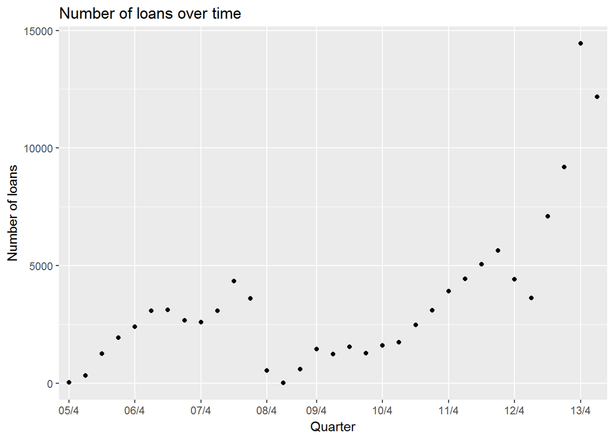

The number of loans fluctuates over time. There is a steep increase towards the end of the period of investigation.

## BorrowerRate

```
##    Min. 1st Qu.  Median    Mean 3rd Qu.    Max.
##  0.0000  0.1340  0.1840  0.1928  0.2500  0.4975
```

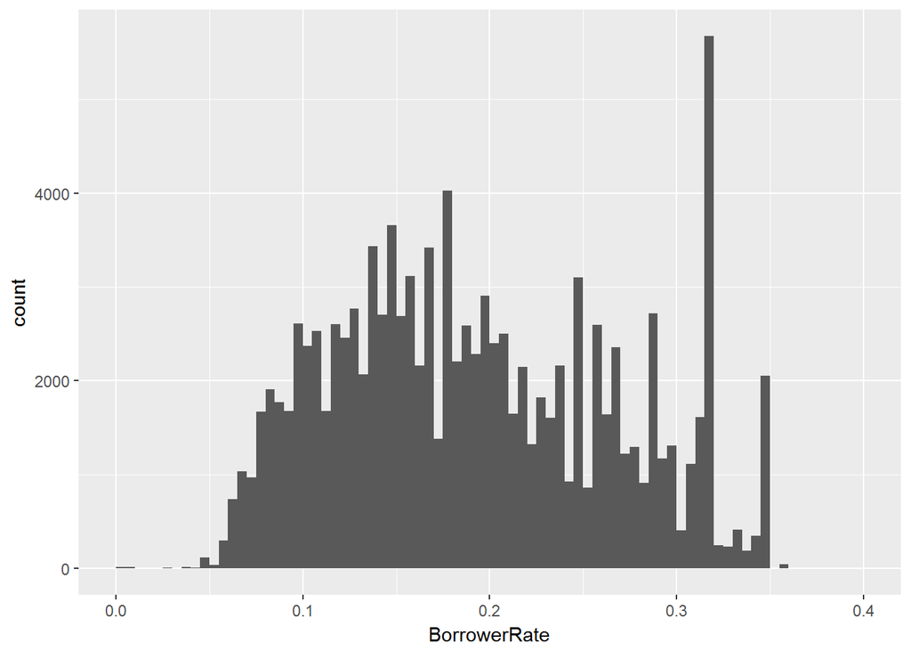

```
## [1] "Modus:"
```

```
## [1] "0.3177"
```

The mean interest rate for all loans is about 19%. The distribution approximates a normal distribution with a high peak at exactly 31.77%. This might be a problem with the data or could be a result of a special offer for loans at this rate.

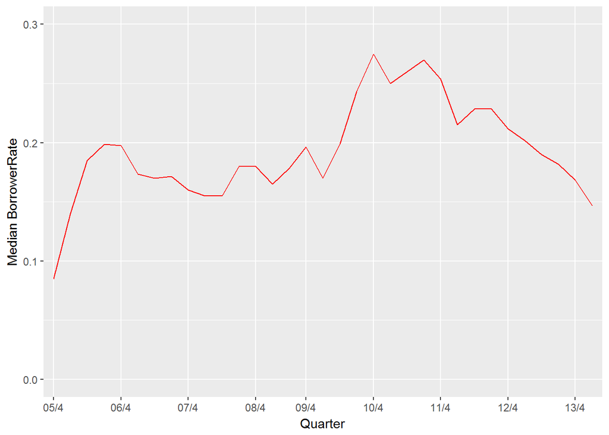

Overall, the median rate is surprisingly stable over time. However, there is an increase in the second half of 2010 and a decrease on the previous level from 2012 onwards.

## Prosper Score

```
##    Min. 1st Qu.  Median    Mean 3rd Qu.    Max.    NA's
##    1.00    4.00    6.00    5.95    8.00   11.00   29084
```

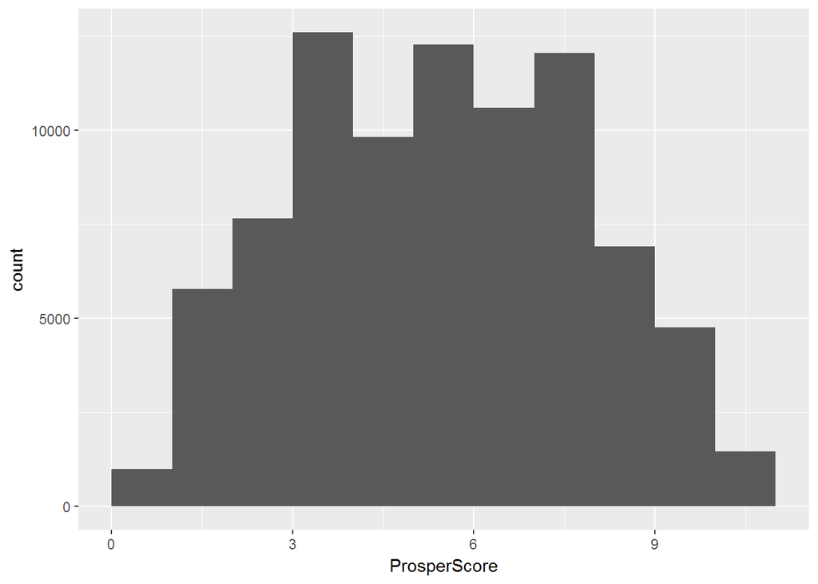

## Amount

```
##    Min. 1st Qu.  Median    Mean 3rd Qu.    Max.
##    1000    4000    6500    8337   12000   35000
```

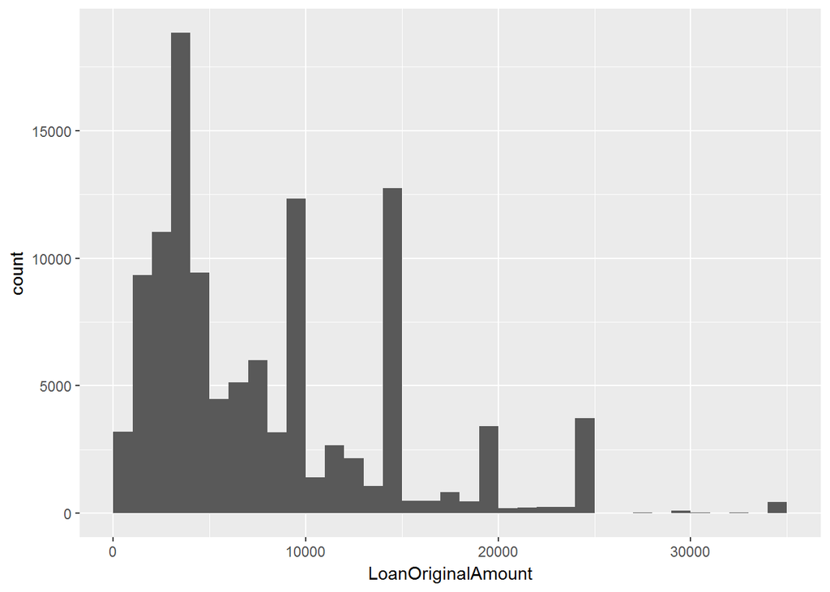

The amount of the loans ranges from $1,000 to $35,000 with a median loan of $6,500. There are several suspisious peaks in the distribution.

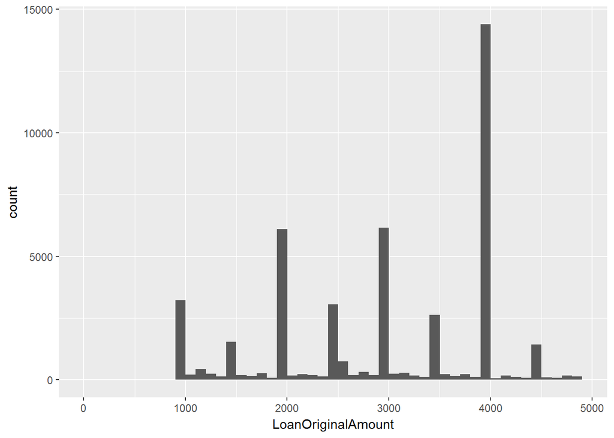

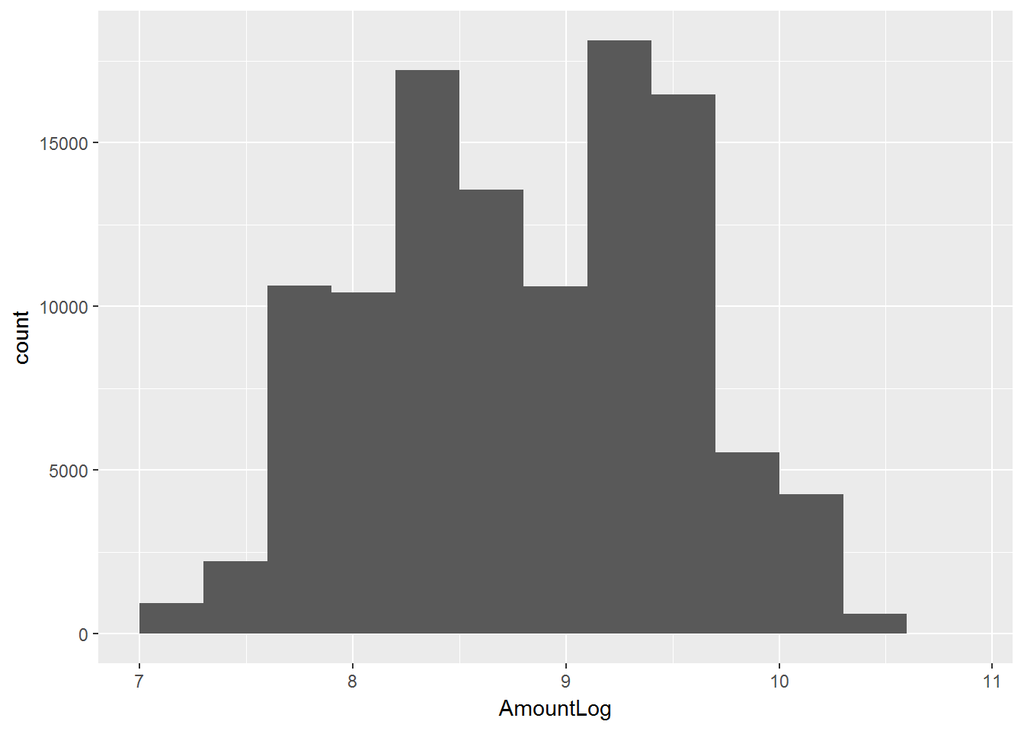

Zooming in, I see that these peaks represent multiplikates of $500 and $1000. There are peaks in the distribution at $4,000, $10,000, $15,000, $20,000 and $25,000. Because of the skewed distribution I decide to use a log scale for this variable, leading to a distribution that is closer to a normal distribution.

## Monthly income

```
##    Min. 1st Qu.  Median    Mean 3rd Qu.    Max.
##       0    3200    4667    5608    6825 1750003
```

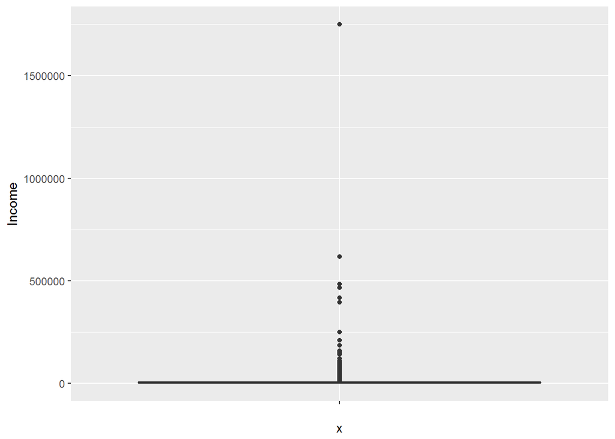

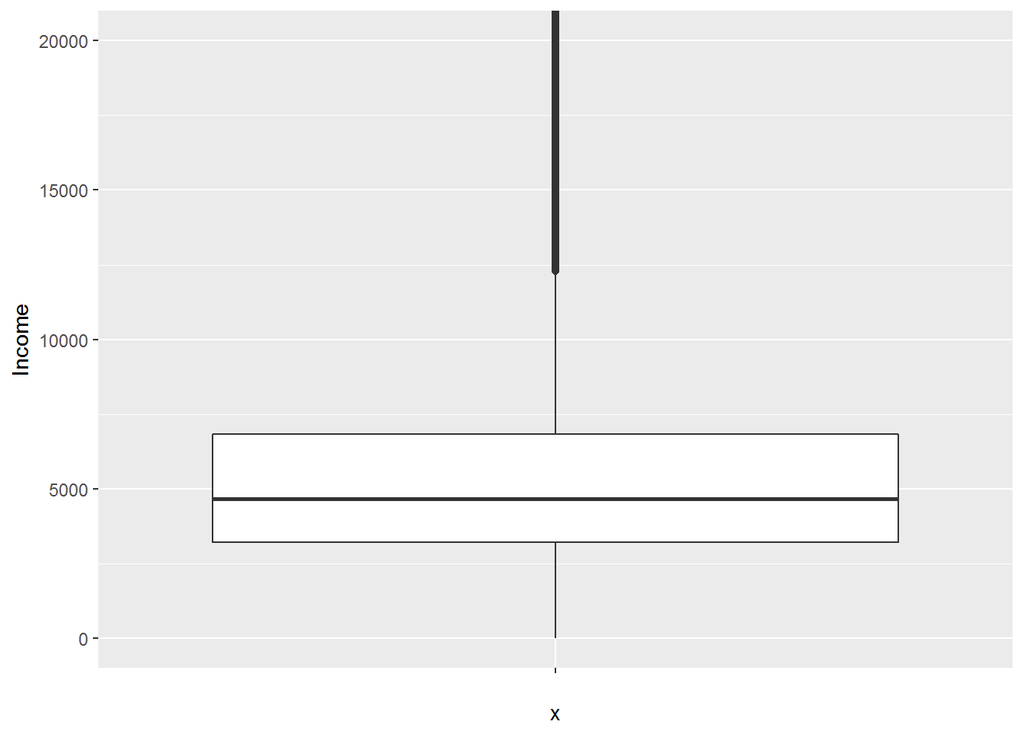

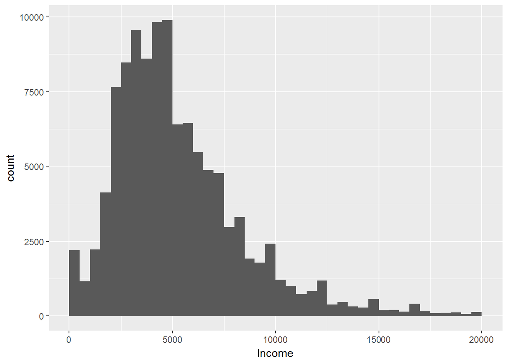

The Boxplot reveals that there is one extreme outlier with $1,750,003 monthly income, a yearly income of moren than $21 Million. It is not impossible, but highly unlikely that someone with such a high income needs a loan of a few thousand Dollars. Therefore, I assume an error in the data and exclude this case from  
further analyses.

Because of the skewed distribution, I decide to use a log scale for the income variable.

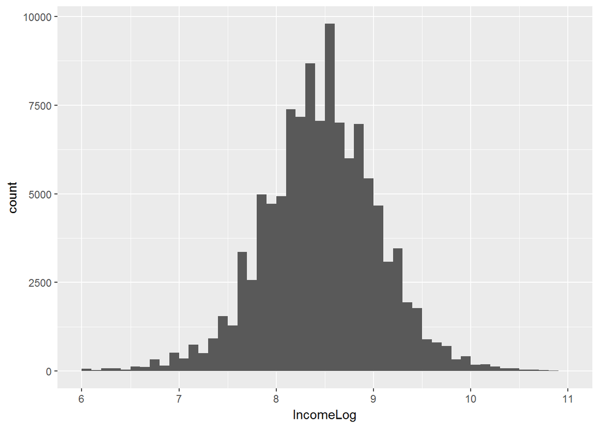

```r
# Excluding cases with unrealistic income
df <- subset(df, Income < 1750000)

# Transform income to log-scale
df$IncomeLog <- log(df$Income+1)
ggplot(aes(x = IncomeLog), data = df) +
  geom_histogram(breaks=seq(6,11, by=0.1))
```

## MonthlyLoanPayment

```
##    Min. 1st Qu.  Median    Mean 3rd Qu.    Max.
##     0.0   131.6   217.7   272.5   371.6  2251.5
```

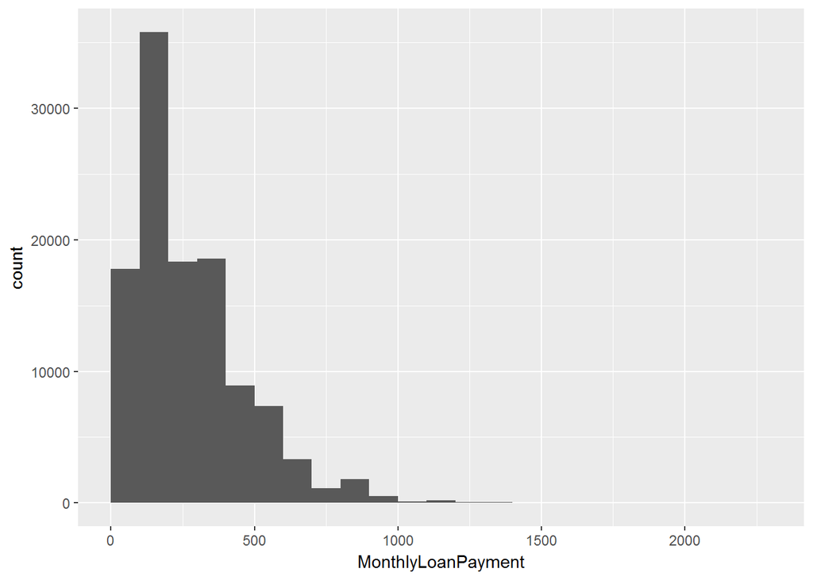

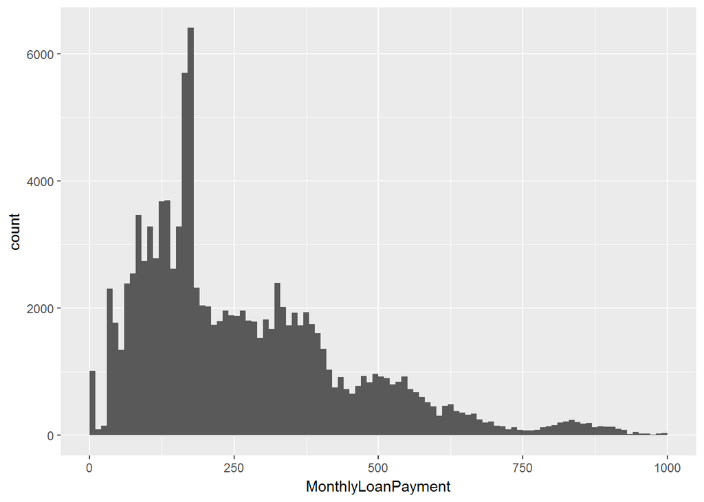

## Monthly payment as share of total amount

```
##  LoanPaymentPerc
##  Min.   :   10.43
##  1st Qu.:   25.51
##  Median :   28.85
##  Mean   :   30.89
##  3rd Qu.:   31.91
##  Max.   :20000.00
```

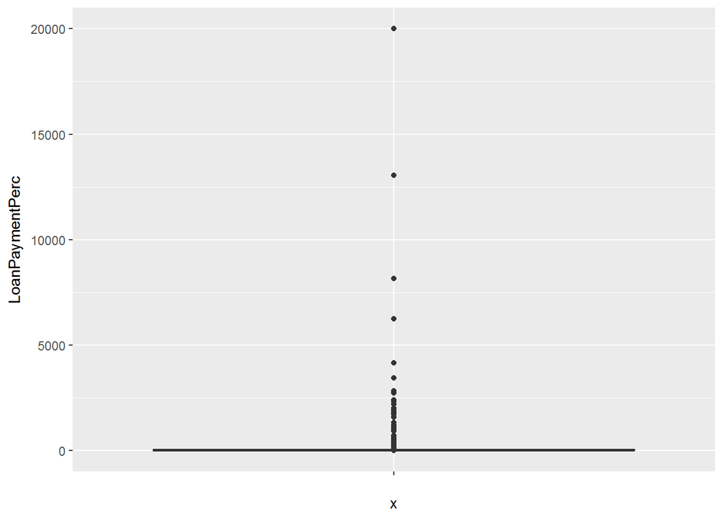

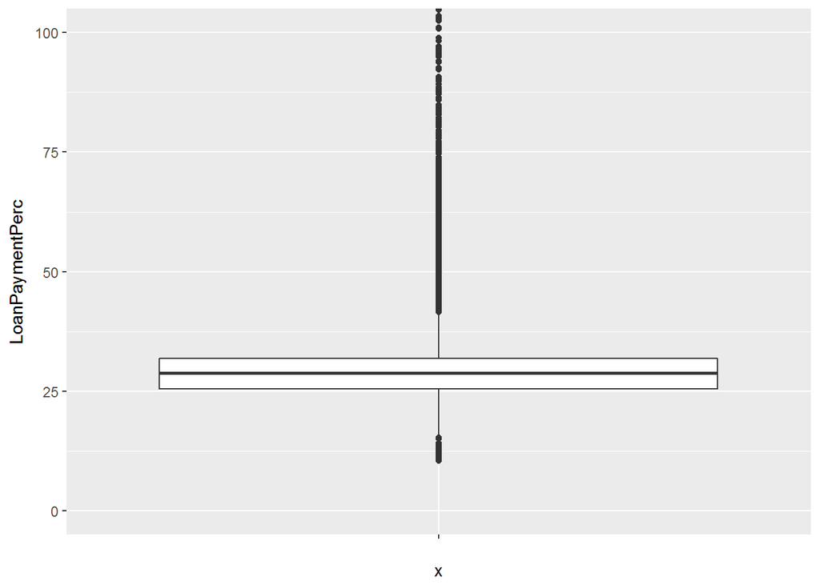

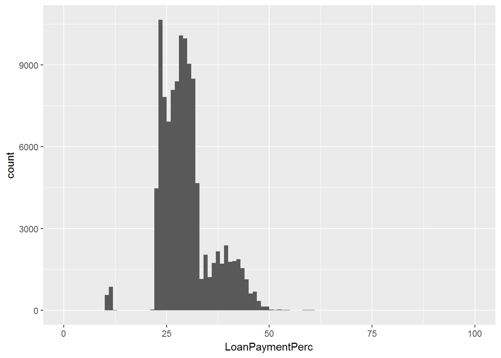

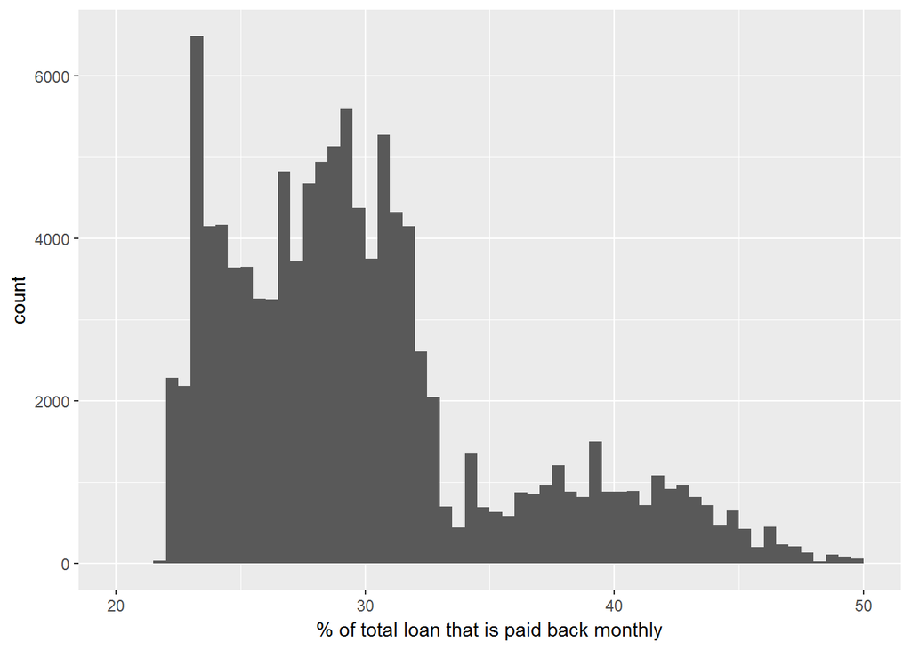

I calculate the share of the monthly payments from the total loan. The majority of payments are about 20%-40% of the total loan. There are some extreme outliers with payments much higher than the total loan. I exclude these cases from the analysis because these do not seem to be valid values to me.

## Term

```
##    Min. 1st Qu.  Median    Mean 3rd Qu.    Max.
##   12.00   36.00   36.00   40.91   36.00   60.00
```

```
##
##  Short Medium   Long
##   1450  86821  24544
```

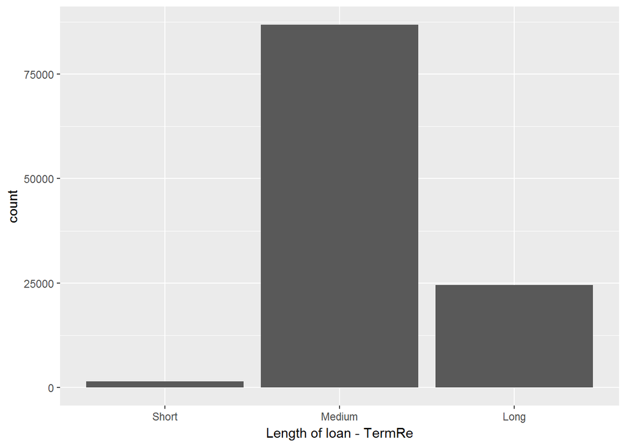

There are only 12, 36 and 60 month values in *term*. Therefore, I recode it to a categorial variable. By far the most loans have a medium duration of 36 month.

## Employment status

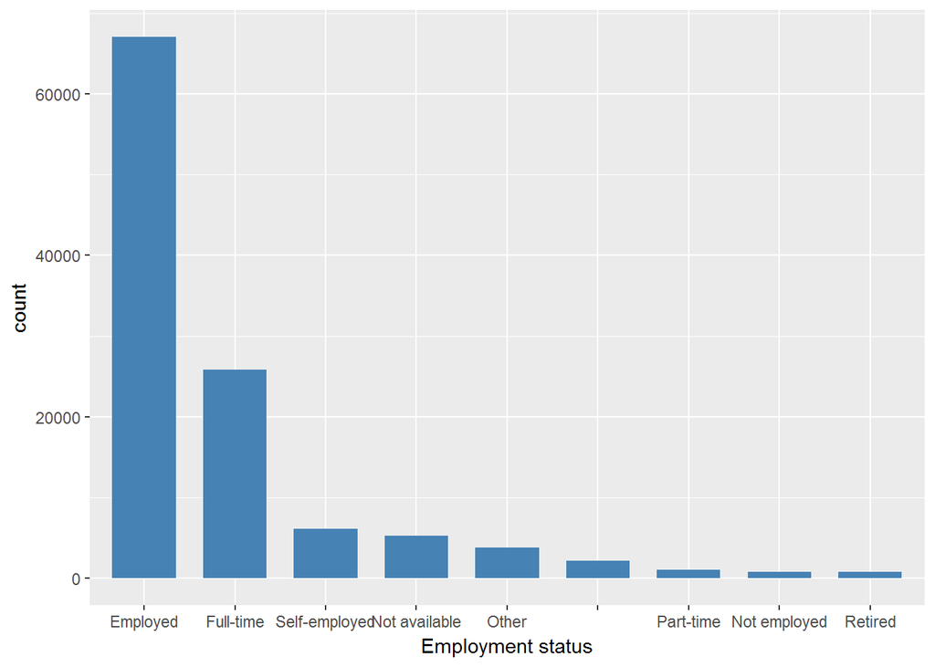

```
##
##                    Employed     Full-time Not available  Not employed
##          2200         67045         25804          5238           824
##         Other     Part-time       Retired Self-employed
##          3797          1045           775          6087
```

The categories of the employment status variable are not mutually exclusive and the missings are coded in different ways. Therefore, I recode the variable. Because I do not want to exclude all missings on this variable in a later regression, I do not mark these cases as “NA” but as “unknown”.

```r
# Recode employment
df$Employment_re<-car::recode(df$EmploymentStatus,
    "c('Employed', 'Full-time') = 'Employed';
    c('Other', 'Not available', '') = 'Unknown' ")
```

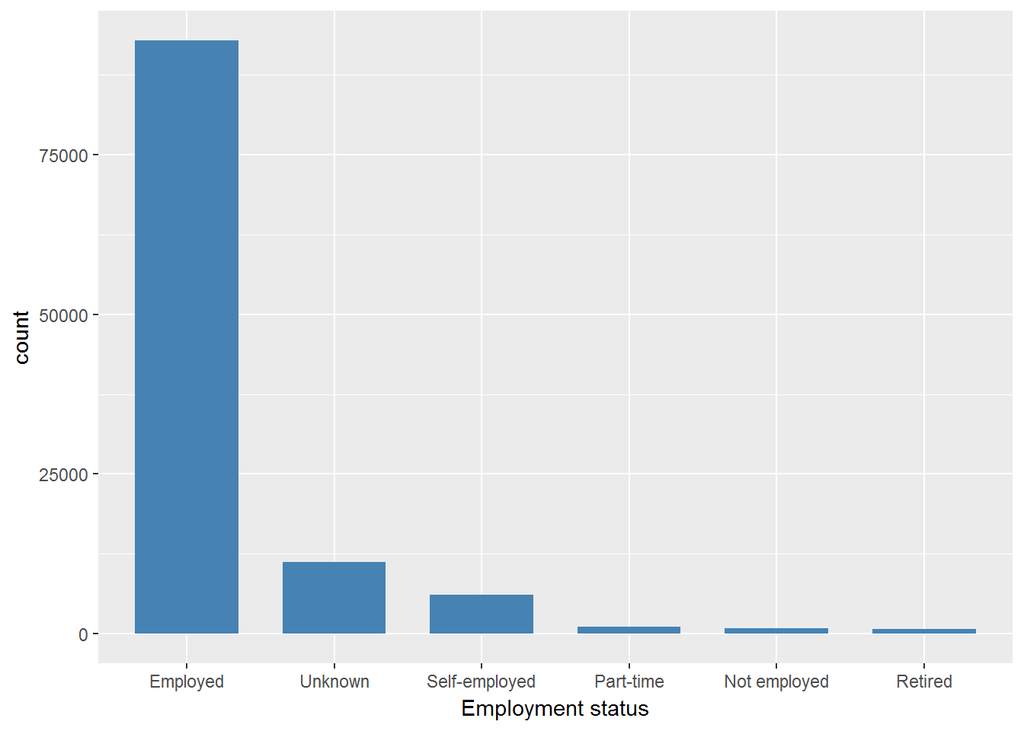

## Homeowners

```
## [1] "Percentage of homeowners:"
```

```
##
## False  True
## 0.494 0.506
```

```
##
##          AK    AL    AR    AZ    CA    CO    CT    DC    DE    FL    GA
##  5387   198  1660   847  1888 14588  2191  1619   379   294  6667  4950
##    HI    IA    ID    IL    IN    KS    KY    LA    MA    MD    ME    MI
##   405   183   593  5841  2054  1050   976   946  2219  2796    98  3551
##    MN    MO    MS    MT    NC    ND    NE    NH    NJ    NM    NV    NY
##  2304  2592   783   324  3057    52   667   547  3082   467  1088  6674
##    OH    OK    OR    PA    RI    SC    SD    TN    TX    UT    VA    VT
##  4154   958  1792  2942   429  1114   188  1721  6798   871  3250   207
##    WA    WI    WV    WY
##  3006  1833   387   148
```

About half of the borrowers are home owners. They come from all 51 US states.

# Loan status

```
##
##              Cancelled             Chargedoff              Completed
##                      5                  11992                  37110
##                Current              Defaulted FinalPaymentInProgress
##                  56575                   4865                    201
##   Past Due (>120 days)   Past Due (1-15 days)  Past Due (16-30 days)
##                     16                    806                    265
##  Past Due (31-60 days)  Past Due (61-90 days) Past Due (91-120 days)
##                    363                    313                    304
```

```
##
##     Completed       Current Def/Cancelled      Past Due
##         37311         56575         16862          2067
```

I recode the loan status to four categories.

## DebtToIncomeRatio

```
##    Min. 1st Qu.  Median    Mean 3rd Qu.    Max.    NA's
##   0.000   0.140   0.220   0.276   0.320  10.010    8481
```

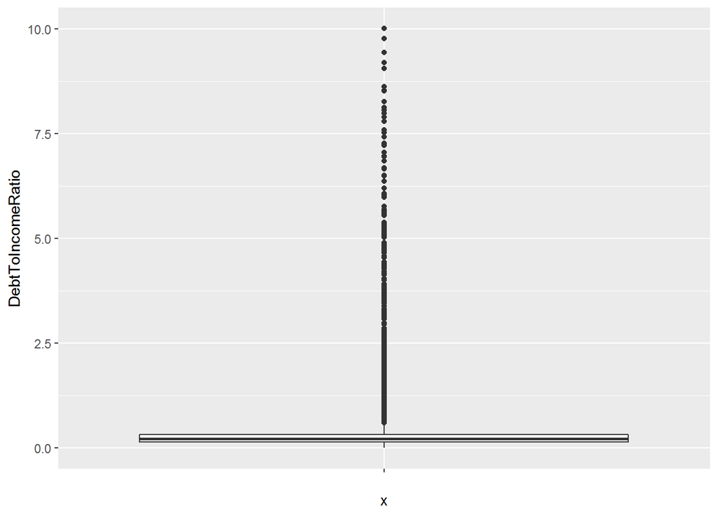

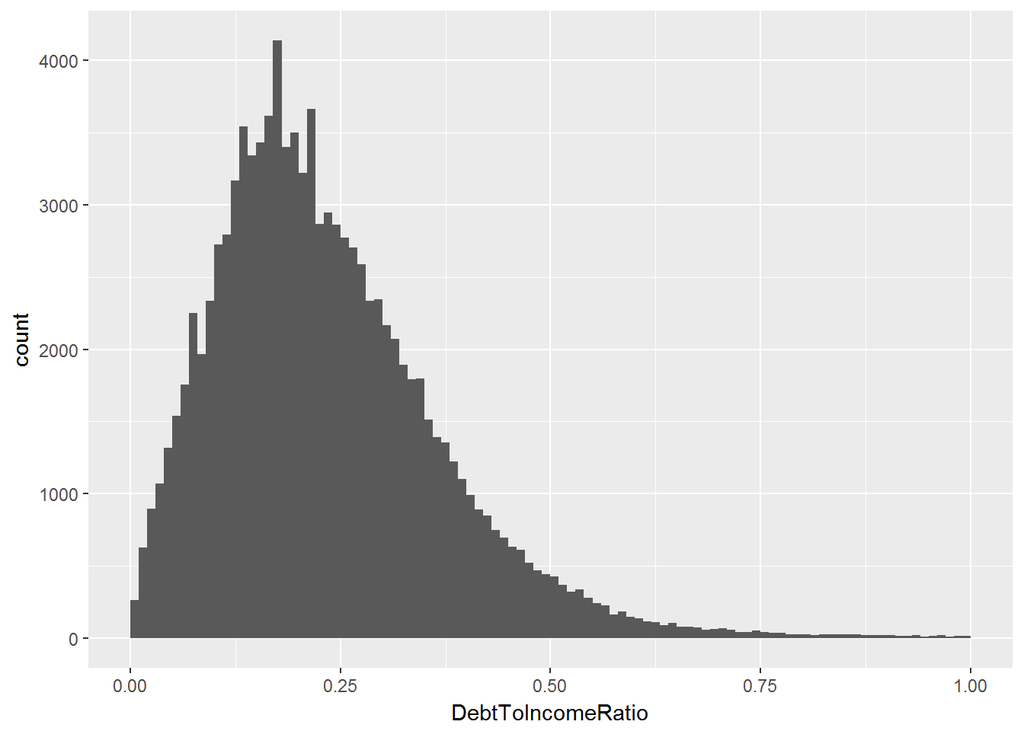

Most borrowers have a *DebtToIncomeRatio* of about 0 to 0.75. However, there is a number of extreme outliers up to 10. Either there are errors in the data, or some people are highly in dept. We should take this distribution into account when interpreting regression results later on.

## Recommendations, InvestmentsFromFriends

```
##     Min.  1st Qu.   Median     Mean  3rd Qu.     Max.
##  0.00000  0.00000  0.00000  0.04759  0.00000 39.00000
```

```
##     Min.  1st Qu.   Median     Mean  3rd Qu.     Max.
##  0.00000  0.00000  0.00000  0.02322  0.00000 33.00000
```

Only few borrowers have a value other than “0” for recommendations and investments from friends. Because of this low information value, I will not consider these variables in the following analysis.

# Univariate Analysis

### What is the structure of your dataset?

There are 113,937 observations and 82 variables.

### What is/are the main feature(s) of interest in your dataset?

The main feature of interest is the borrower rate. I suspect that certain aspects of the borrower and the loan itself are related to the borrower rate.

### What other features in the dataset do you think will help support your investigation?

In particular, I assume the following features are useful for my predictive model: *Aspects of the borrower** * Prosper scores * Income * Dept to income ratio

*Aspects of the loan** * Amount * Monthly payment relative to loan * Term of the loan

I also assume that other factors such as the recommendations might be related to the interest rate. However, these variables contain little variance and therefore are left out of the further analysis. Occupation could also be interesting, but I would need to combine the many categories in a sensible way, which goes beyond the scope of this EDA.

### Did you create any new variables from existing variables in the dataset?

I calculate the share of the monthly payments from the total loan. I recoded the variable for *employment status* by combining categories. Also, I recoded *term* from a continous to a categorial variable.

### Of the features you investigated, were there any unusual distributions?

*Income* and the *total amount of the loan* exhibited skewed distributions. Therefore, I calculated the logs for these values.

# Bivariate Plots Section

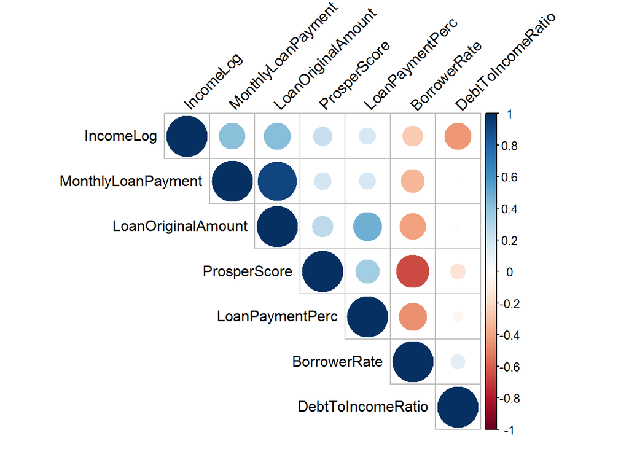

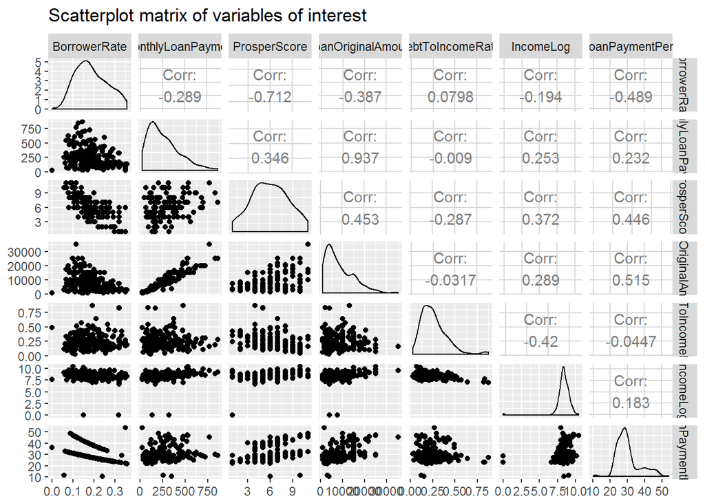

These plots show the correlations between the variables of interest. I proceed with a closer look at variables that show a strong relationship or unusual patterns.

## Scatterplots - Borrower rate and independent variables

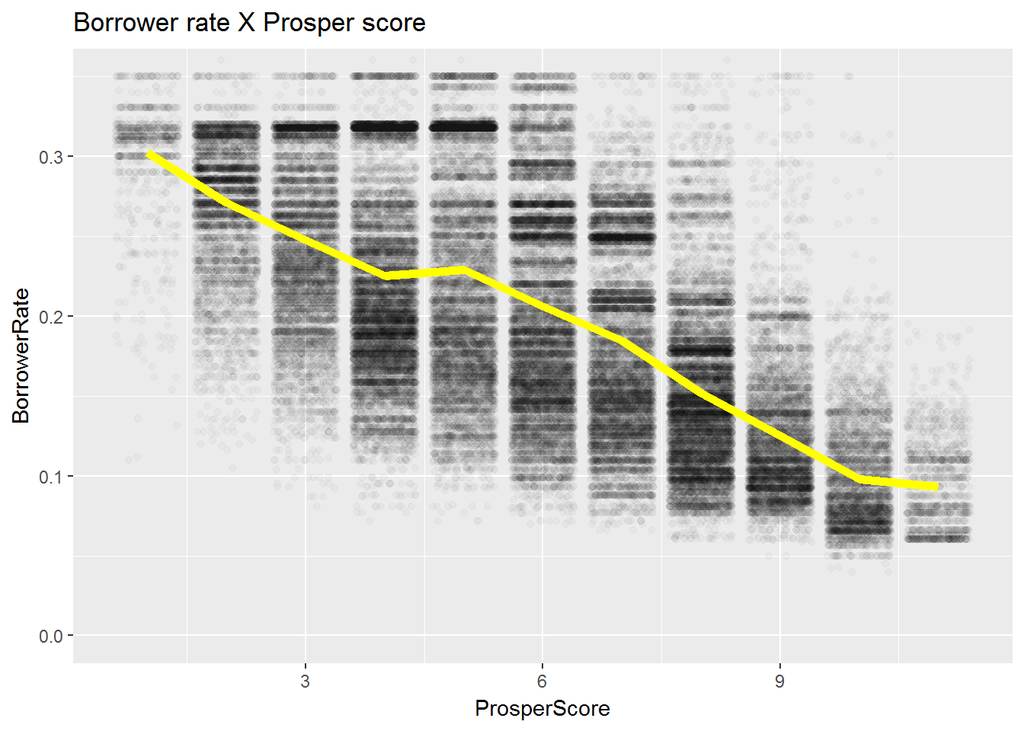

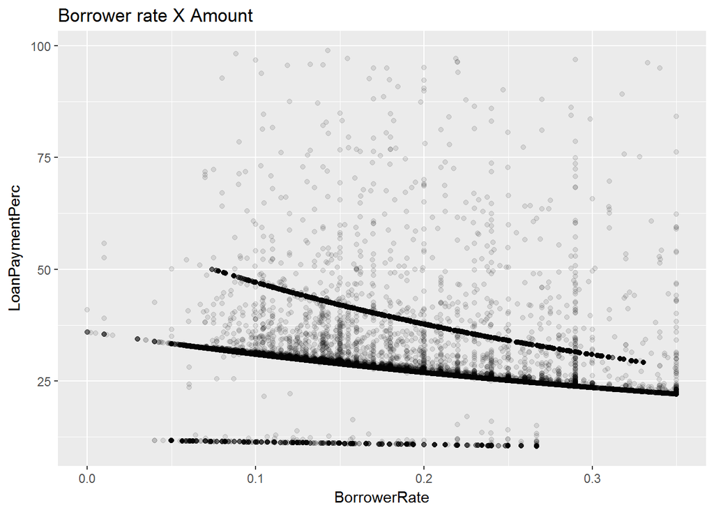

There is a very interesting pattern for the second plot. There is a negative relationship between the *monthly loan payment* (as share of the loan) and *borrower rate*. However, there are different trajectories in the data. This needs more exploration in the multivariate part.

## Scatterplots - independent variables

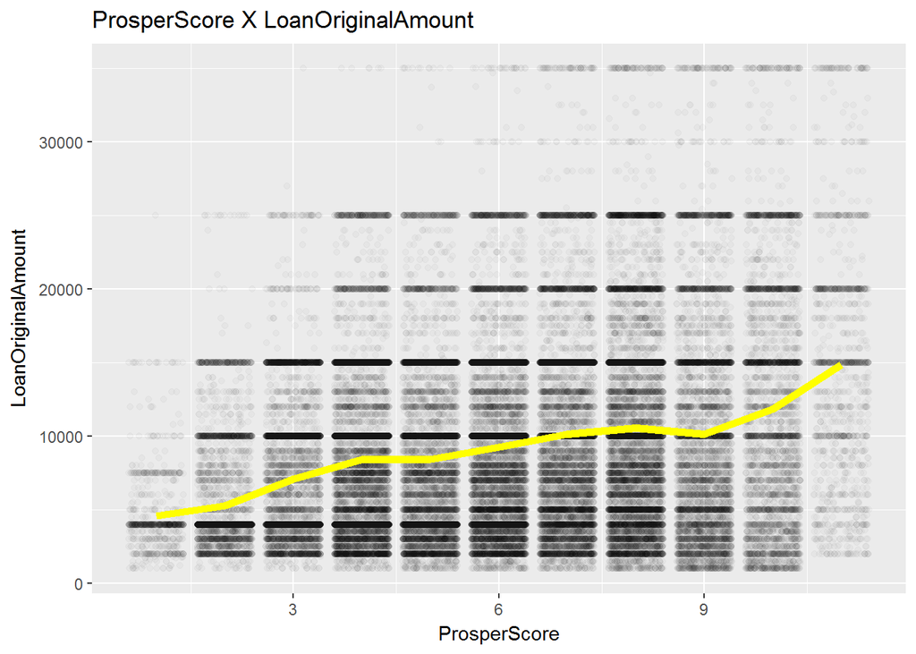

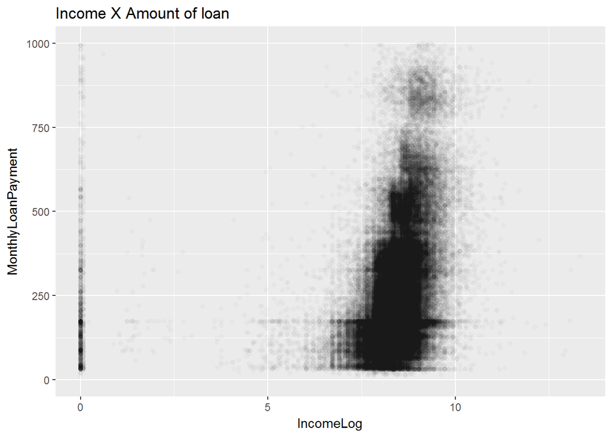

There are also interesting patterns in regard to the independent variables.

## Loan status over time

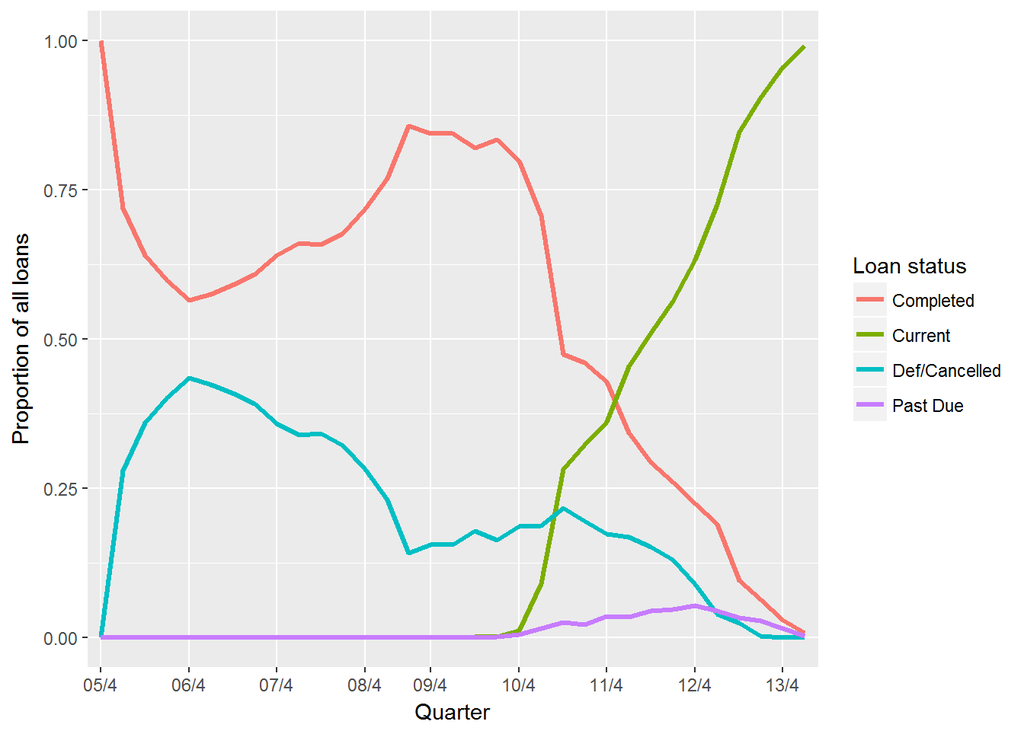

# Bivariate Analysis

### Talk about some of the relationships you observed in this part

Overall, the choosen variables in the data set are highly correlated. Most interesting for the aim of this project are the correlations between *BorrowerRate* and the other variables. There is a negative relationship between *BorrowerRate* and monthly payment (both in absolute terms and as share of the loan), the amount of the loan, and prosper score.

### Did you observe any interesting relationships between the other features (not the main feature(s) of interest)?

The independent variables are also correlated with each other. For example, there is a positive relationship between *personal income* on the one hand, and the *amount*, *monthly payment* and *prosper score* on the other hand. Individuals with a high income recieve bigger loans with better conditions than individuals with little income.